# Evolutionary Computation Laboratory Part 2: **Evolution Strategies**

Lluís A. Belanche

15 dic. 2022

```r
library(cmaesr)
```

## Introduction

The *cmaesr* package implements the popular Covariance Matrix Adaptation - Evolution Strategy optimizer for non-linear, non-convex numerical optimization problems in pure R.

Please refer to:

- https://cran.r-project.org/web/packages/cmaesr/index.html
- https://github.com/jakobbossek/cmaesr

for a complete introduction to the software. Please address questions and missing features about the *cmaesr* package to the author Jakob Bossek at j.bossek@gmail.com.

## Example 1

Assume we want to minimize the 2D Ackley Function. To accomplish this task we first need to define the objective function as a *smoof* function (unless it is already a built-in function, which is the case). This function is then passed with some control arguments to the main function of the package, *cmaes* (see below).

The *Ackley* function is widely used for testing optimization algorithms. In its two-dimensional form ($d=2$), as shown in the plots, it is characterized by a nearly flat outer region, and a large hole at the centre. The function poses a high risk for optimization algorithms, particularly hillclimbing algorithms, to be trapped in one of its many local minima.

Recommended variable values are: $a = 20, b = 0.2$ and $c = 2\pi$.

```r
library(ggplot2)
library(plot3D)

# first generate the objective smoof function (and plot it)
obj.fn = makeAckleyFunction(dimensions = 2L)
print(obj.fn)
## Single-objective function
## Name: 2-d Ackley Function
## Description: no description
## Tags: single-objective, continuous, multimodal, differentiable, non-separable, scalable
## Noisy: FALSE
## Minimize: TRUE
## Constraints: TRUE
## Number of parameters: 2
##            Type len Def        Constr Req Tunable Trafo
## x numericvector   2   - -32.8 to 32.8   -    TRUE     -
## Global optimum objective value of 0.0000 at
##   x1 x2
## 1  0  0
print(autoplot(obj.fn))
```

[figure not shown]

```r
plot3D(obj.fn, length.out = 50L, contour = TRUE)
```

[figure not shown]

Note that the function has a global optimum objective value of 0 at the origin (this information is available upon printing the R object). The function is usually evaluated on the hypercube $[-32.768, 32.768]$, although it may also be restricted to a smaller domain:

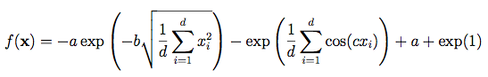

```r
res = cmaes(
    obj.fn,
    monitor = makeSimpleMonitor(),
    control = list(
        sigma = 1.5, # initial step size
        lambda = 50, # number of offspring
        stop.ons = c(
            list(stopOnMaxIters(100)), # stop after 100 iterations
            getDefaultStoppingConditions() # or after default stopping conditions
        )
    )
)
## Starting optimization.
## Iteration    1: x1:    -2.0598   x2:    +8.9332, y =   +14.7349
## Iteration    2: x1:    +2.7342   x2:    +5.6605, y =   +13.7681
## Iteration    3: x1:    +0.6018   x2:    +1.4023, y =    +6.1556
## Iteration    4: x1:    -0.0175   x2:    +1.3441, y =    +4.9370
## Iteration    5: x1:    -0.0399   x2:    +1.3222, y =    +4.8266
## Iteration    6: x1:    +0.9579   x2:    -0.1069, y =    +2.8702
## Iteration    7: x1:    +0.9579   x2:    -0.1069, y =    +2.8702
## Iteration    8: x1:    +0.0836   x2:    -0.0951, y =    +0.7431
## Iteration    9: x1:    -0.0707   x2:    +0.0846, y =    +0.6106
## Iteration   10: x1:    +0.0148   x2:    -0.0177, y =    +0.0792
## Iteration   11: x1:    -0.0093   x2:    +0.0143, y =    +0.0561
## Iteration   12: x1:    -0.0093   x2:    +0.0143, y =    +0.0561
## Iteration   13: x1:    -0.0123   x2:    -0.0111, y =    +0.0543
## Iteration   14: x1:    +0.0144   x2:    +0.0079, y =    +0.0537
## Iteration   15: x1:    -0.0028   x2:    -0.0014, y =    +0.0091
## Iteration   16: x1:    +0.0014   x2:    +0.0024, y =    +0.0082
## Iteration   17: x1:    -0.0000   x2:    +0.0007, y =    +0.0019
## Iteration   18: x1:    -0.0004   x2:    -0.0002, y =    +0.0013
## Iteration   19: x1:    +0.0001   x2:    +0.0002, y =    +0.0005
## Iteration   20: x1:    -0.0001   x2:    -0.0000, y =    +0.0004
## Iteration   21: x1:    +0.0001   x2:    -0.0000, y =    +0.0002
## Iteration   22: x1:    -0.0000   x2:    +0.0000, y =    +0.0000
## Iteration   23: x1:    -0.0000   x2:    -0.0000, y =    +0.0000
## Iteration   24: x1:    -0.0000   x2:    -0.0000, y =    +0.0000
## Iteration   25: x1:    -0.0000   x2:    +0.0000, y =    +0.0000
## Iteration   26: x1:    -0.0000   x2:    +0.0000, y =    +0.0000
## Iteration   27: x1:    +0.0000   x2:    -0.0000, y =    +0.0000
## Iteration   28: x1:    +0.0000   x2:    -0.0000, y =    +0.0000
## Iteration   29: x1:    -0.0000   x2:    -0.0000, y =    +0.0000
## Iteration   30: x1:    +0.0000   x2:    +0.0000, y =    +0.0000
## Iteration   31: x1:    -0.0000   x2:    -0.0000, y =    +0.0000
## Iteration   32: x1:    -0.0000   x2:    +0.0000, y =    +0.0000
## Iteration   33: x1:    -0.0000   x2:    +0.0000, y =    +0.0000
## Iteration   34: x1:    -0.0000   x2:    +0.0000, y =    +0.0000
## Optimization terminated.
print(res)
## Best parameter      : x=-4.26e-08,3....
## Best fitness value  : 1.20746e-07
## Termination         : Addition of 0.1 times sigma does not change mean value.
##   #Iterations       : 33
##   #Evaluations      : 1700
##   Time              : 0 (secs)
```

The results are (usually but not always) very good indeed.

## Setting up a user-defined objective function by hand

For illlustration purposes, let us consider the (toy) problem of finding the (global) minimum of the multimodal target function $f(x) = x sin(3x)$ on the closed interval $[0, 2\pi]$. We define our target function via the *makeSingleObjectiveFunction()* method providing a name, the function itself and a parameter set. We can display the function within the box constraints with *ggplot*.

```r
obj.fn = makeSingleObjectiveFunction(
  name = "This is my first function name",
  fn = function(x) x * sin(3*x),
  par.set = makeNumericParamSet("x", len = 1L, lower = 0, upper = 2 * pi)
)

print(obj.fn)
## Single-objective function
## Name: This is my first function name
## Description: no description
## Tags:
## Noisy: FALSE
## Minimize: TRUE
## Constraints: TRUE
## Number of parameters: 1
##            Type len Def    Constr Req Tunable Trafo
## x numericvector   1   - 0 to 6.28   -    TRUE     -
print(getParamSet(obj.fn))
```

```
##            Type len Def    Constr Req Tunable Trafo
## x numericvector   1   - 0 to 6.28   -    TRUE     -
```

```r
print(autoplot(obj.fn))
```

[figure not shown]